# Chapter 7 Lab 3 - Naive Bayes

# Goal

In this lab, we, again, will try to predict players’ skill level, i.e., column `SkillLevel`, which takes integer value between 0 and 3, with 0 being novice level and 3 expert. The `Naive Bayes` (NB) implementation in the `caret` package will be used.

## Brief refresher

`NB` estimates class probability by collating, using Bayes’ Rule, independent variables’ estimated probabilities from the training data. It assumes that the independent variables are conditionally independent from one another given class values, which simplifies the computations and allows it to run quickly.

## Preparation

```r
# install packages: should be run only once

options(repos = c(CRAN = "http://cran.rstudio.com"))
install.packages("caret", dependencies = TRUE)
install.packages("klaR", dependencies = TRUE)
# import the "caret" library and its dependency, klaR, which implements the naive bayes classifier
library("klaR")
library("caret")
```

# Step 1: Load the data set

```r
# we are assuming the data file is in the current directory. If not, you may want to set the current directory to where the data file is or adjust the path in the read.csv line below.

# read the CSV file
DotaData <- read.csv("DoTalicious_cleaned1000players.csv", fileEncoding="UTF-8-BOM")
summary(DotaData)
```

```
##     PlayerID       GamesPlayed         GamesWon         GamesLeft
##  Min.   :   0.0   Min.   :   0.00   Min.   :   0.00   Min.   : 0.000
##  1st Qu.: 242.8   1st Qu.:   3.00   1st Qu.:   1.00   1st Qu.: 0.000
##  Median : 499.5   Median :  15.00   Median :   7.00   Median : 0.000
##  Mean   : 497.7   Mean   :  92.24   Mean   :  50.31   Mean   : 1.649
##  3rd Qu.: 750.2   3rd Qu.:  90.00   3rd Qu.:  47.25   3rd Qu.: 2.000
##  Max.   :1000.0   Max.   :3156.00   Max.   :1764.00   Max.   :40.000
##     Ditches            Points        SkillLevel            Kills
##  Min.   : 0.0000   Min.   : 626.8   Length:868         Min.   :    0.0
##  1st Qu.: 0.0000   1st Qu.: 962.1   Class :character   1st Qu.:   11.0
##  Median : 0.0000   Median : 996.7   Mode  :character   Median :   74.0
##  Mean   : 0.7108   Mean   :1014.8                      Mean   :  608.0
##  3rd Qu.: 1.0000   3rd Qu.:1046.7                      3rd Qu.:  512.8
##  Max.   :18.0000   Max.   :2010.2                      Max.   :23742.0
##   KillsPerMin         Deaths           Assists         CreepsKilled
##  Min.   :0.0000   Min.   :    0.0   Min.   :    0.0   Min.   :     0.0
##  1st Qu.:0.0900   1st Qu.:   17.0   1st Qu.:   18.0   1st Qu.:   159.5
##  Median :0.1300   Median :   92.5   Median :  124.0   Median :   979.0
##  Mean   :0.1316   Mean   :  544.5   Mean   :  950.7   Mean   :  7628.0
##  3rd Qu.:0.1700   3rd Qu.:  554.0   3rd Qu.:  863.5   3rd Qu.:  6723.0
##  Max.   :0.4200   Max.   :16988.0   Max.   :34390.0   Max.   :372360.0
##   CreepsDenied     NeutralsKilled    TowersDestroyed   RaxsDestroyed
##  Min.   :    0.0   Min.   :    0.0   Min.   :   0.00   Min.   :   0.00
##  1st Qu.:   12.0   1st Qu.:   16.0   1st Qu.:   1.00   1st Qu.:   0.00
##  Median :   76.0   Median :  145.5   Median :   7.00   Median :   3.00
##  Mean   :  676.9   Mean   : 1258.3   Mean   :  70.71   Mean   :  29.71
##  3rd Qu.:  540.8   3rd Qu.: 1126.8   3rd Qu.:  61.50   3rd Qu.:  26.00
##  Max.   :43910.0   Max.   :42900.0   Max.   :2601.00   Max.   :1141.00
##   TotalTime
##  Length:868
##  Class :character
##  Mode  :character
##
##
##
```

Clean up and set the correct data type.

```r
# convert TotalTime
DotaData$TotalTime <- as.numeric(DotaData$TotalTime)
# exclude the row with SillLevel = SkillLevelNull
DotaData$SkillLevel <- as.factor(DotaData$SkillLevel)
DotaData <- DotaData[!(DotaData$SkillLevel == " SkillLevelNull"),]

# use factor in place of as.factor to remove " SkillLevelNull" from the list of factors
DotaData$SkillLevel <- factor(DotaData$SkillLevel)

# exclude PlayerID
DotaData <- DotaData[-1]

#removing any rows with NA
DotaData = na.omit(DotaData)

summary(DotaData)
```

```
##   GamesPlayed         GamesWon         GamesLeft         Ditches
##  Min.   :   1.00   Min.   :   0.00   Min.   : 0.000   Min.   : 0.0000
##  1st Qu.:   3.00   1st Qu.:   1.00   1st Qu.: 0.000   1st Qu.: 0.0000
##  Median :  15.00   Median :   7.00   Median : 0.000   Median : 0.0000
##  Mean   :  92.35   Mean   :  50.39   Mean   : 1.649   Mean   : 0.7125
##  3rd Qu.:  89.75   3rd Qu.:  47.75   3rd Qu.: 2.000   3rd Qu.: 1.0000
##  Max.   :3156.00   Max.   :1764.00   Max.   :40.000   Max.   :18.0000
##      Points       SkillLevel     Kills          KillsPerMin
##  Min.   : 626.8   0:446      Min.   :    0.0   Min.   :0.0000
##  1st Qu.: 962.3   1:391      1st Qu.:   11.0   1st Qu.:0.0900
##  Median : 996.7   2: 17      Median :   74.0   Median :0.1300
##  Mean   :1015.0   3: 12      Mean   :  608.8   Mean   :0.1318
##  3rd Qu.:1047.2              3rd Qu.:  516.2   3rd Qu.:0.1700
##  Max.   :2010.2              Max.   :23742.0   Max.   :0.4200
##      Deaths            Assists         CreepsKilled       CreepsDenied
##  Min.   :    0.00   Min.   :    0.0   Min.   :     9.0   Min.   :    0.0
##  1st Qu.:   17.25   1st Qu.:   18.0   1st Qu.:   160.2   1st Qu.:   12.0
##  Median :   92.50   Median :  124.0   Median :   979.0   Median :   76.0
##  Mean   :  545.09   Mean   :  952.0   Mean   :  7637.0   Mean   :  678.0
##  3rd Qu.:  554.00   3rd Qu.:  866.5   3rd Qu.:  6690.8   3rd Qu.:  542.2
##  Max.   :16988.00   Max.   :34390.0   Max.   :372360.0   Max.   :43910.0
##  NeutralsKilled    TowersDestroyed   RaxsDestroyed       TotalTime
##  Min.   :    0.0   Min.   :   0.00   Min.   :   0.00   Min.   :   1349
##  1st Qu.:   16.0   1st Qu.:   1.00   1st Qu.:   0.00   1st Qu.:   6255
##  Median :  145.5   Median :   7.00   Median :   3.00   Median :  35070
##  Mean   : 1258.7   Mean   :  70.79   Mean   :  29.74   Mean   : 228343
##  3rd Qu.: 1118.5   3rd Qu.:  61.00   3rd Qu.:  26.00   3rd Qu.: 220815
##  Max.   :42900.0   Max.   :2601.00   Max.   :1141.00   Max.   :4294920
```

# Step 2: Set up training and test set

This is similar to the previous lab.

```r
# setting the random seed
set.seed(101)
#Spliting data as training and test set. Using createDataPartition() function from caret
indxTrain <- createDataPartition(y = DotaData$SkillLevel,p = 0.75,list = FALSE)
training <- DotaData[indxTrain,]
testing <- DotaData[-indxTrain,]
summary(training)
```

```
##   GamesPlayed         GamesWon         GamesLeft         Ditches
##  Min.   :   1.00   Min.   :   0.00   Min.   : 0.000   Min.   : 0.0000
##  1st Qu.:   3.00   1st Qu.:   1.00   1st Qu.: 0.000   1st Qu.: 0.0000
##  Median :  16.00   Median :   7.00   Median : 0.000   Median : 0.0000
##  Mean   :  92.07   Mean   :  50.69   Mean   : 1.639   Mean   : 0.6882
##  3rd Qu.:  90.00   3rd Qu.:  47.50   3rd Qu.: 2.000   3rd Qu.: 1.0000
##  Max.   :3156.00   Max.   :1764.00   Max.   :40.000   Max.   :15.0000
##      Points       SkillLevel     Kills          KillsPerMin
##  Min.   : 626.8   0:335      Min.   :    0.0   Min.   :0.0000
##  1st Qu.: 963.9   1:294      1st Qu.:   11.0   1st Qu.:0.0900
##  Median :1000.0   2: 13      Median :   74.0   Median :0.1300
##  Mean   :1016.0   3:  9      Mean   :  616.5   Mean   :0.1332
##  3rd Qu.:1044.7              3rd Qu.:  514.5   3rd Qu.:0.1700
##  Max.   :2010.2              Max.   :23742.0   Max.   :0.4200
##      Deaths           Assists         CreepsKilled     CreepsDenied
##  Min.   :    0.0   Min.   :    0.0   Min.   :     9   Min.   :    0.0
##  1st Qu.:   16.0   1st Qu.:   18.0   1st Qu.:   156   1st Qu.:   12.0
##  Median :  100.0   Median :  130.0   Median :   991   Median :   79.0
##  Mean   :  539.6   Mean   :  959.8   Mean   :  7558   Mean   :  674.8
##  3rd Qu.:  548.5   3rd Qu.:  882.0   3rd Qu.:  6528   3rd Qu.:  541.5
##  Max.   :16988.0   Max.   :34390.0   Max.   :372360   Max.   :43910.0
##  NeutralsKilled  TowersDestroyed   RaxsDestroyed       TotalTime
##  Min.   :    0   Min.   :   0.00   Min.   :   0.00   Min.   :   1349
##  1st Qu.:   15   1st Qu.:   1.00   1st Qu.:   0.00   1st Qu.:   5970
##  Median :  156   Median :   7.00   Median :   3.00   Median :  36540
##  Mean   : 1264   Mean   :  70.42   Mean   :  29.71   Mean   : 225830
##  3rd Qu.: 1073   3rd Qu.:  60.00   3rd Qu.:  25.00   3rd Qu.: 227100
##  Max.   :42900   Max.   :2601.00   Max.   :1141.00   Max.   :4294920
```

```r
summary(testing)
```

```
##   GamesPlayed         GamesWon        GamesLeft         Ditches
##  Min.   :   1.00   Min.   :  0.00   Min.   : 0.000   Min.   : 0.000
##  1st Qu.:   3.00   1st Qu.:  1.00   1st Qu.: 0.000   1st Qu.: 0.000
##  Median :  13.00   Median :  6.00   Median : 0.000   Median : 0.000
##  Mean   :  93.19   Mean   : 49.46   Mean   : 1.679   Mean   : 0.786
##  3rd Qu.:  85.00   3rd Qu.: 49.00   3rd Qu.: 2.000   3rd Qu.: 1.000
##  Max.   :1362.00   Max.   :816.00   Max.   :18.000   Max.   :18.000
##      Points       SkillLevel     Kills          KillsPerMin
##  Min.   : 691.3   0:111      Min.   :    0.0   Min.   :0.0000
##  1st Qu.: 954.4   1: 97      1st Qu.:   12.5   1st Qu.:0.0800
##  Median : 994.3   2:  4      Median :   69.0   Median :0.1200
##  Mean   :1011.7   3:  3      Mean   :  585.6   Mean   :0.1276
##  3rd Qu.:1054.5              3rd Qu.:  529.5   3rd Qu.:0.1700
##  Max.   :1592.6              Max.   :11457.0   Max.   :0.3700
##      Deaths          Assists         CreepsKilled     CreepsDenied
##  Min.   :   2.0   Min.   :    0.0   Min.   :    10   Min.   :    0.0
##  1st Qu.:  21.5   1st Qu.:   18.5   1st Qu.:   183   1st Qu.:   12.0
##  Median :  78.0   Median :  100.0   Median :   914   Median :   69.0
##  Mean   : 561.6   Mean   :  928.7   Mean   :  7875   Mean   :  687.9
##  3rd Qu.: 569.0   3rd Qu.:  783.0   3rd Qu.:  6884   3rd Qu.:  538.0
##  Max.   :9322.0   Max.   :14645.0   Max.   :142043   Max.   :13030.0
##  NeutralsKilled  TowersDestroyed  RaxsDestroyed      TotalTime
##  Min.   :    0   Min.   :   0.0   Min.   :  0.00   Min.   :   1354
##  1st Qu.:   19   1st Qu.:   1.0   1st Qu.:  0.00   1st Qu.:   7080
##  Median :  116   Median :   7.0   Median :  3.00   Median :  29820
##  Mean   : 1242   Mean   :  71.9   Mean   : 29.85   Mean   : 235952
##  3rd Qu.: 1218   3rd Qu.:  64.0   3rd Qu.: 31.00   3rd Qu.: 215430
##  Max.   :21770   Max.   :1501.0   Max.   :662.00   Max.   :3557400
```

## Data Standardization

For `NB`, there is no need to preprocess the data other than dealing with missing values, as it is not prone to scaling issues.

# Step 3: Apply the Naive Bayes model

Now, we are applying the `Naive Bayes` model on the data. There will be some printouts as the result of running the `train` method, but you could ignore them.

```r
set.seed(101)
ctrl <- trainControl(method="repeatedcv", number = 10, repeats = 3)
nb_model <- suppressWarnings(train(SkillLevel ~ ., data = training, method = "nb", trControl = ctrl, tuneLength = 20))
```

Note that the above `train` function looks almost the same as the `train` function in Lab 7.2 on `KNN`. The only difference is that we set the `method` parameter to *nb* instead of *knn*, and that’s the beauty of `caret`. It provides a wrapper that makes applying different methods efforstless.

Print out details of the model.

```r
#Naive Bayes model of the training
nb_model
```

```
## Naive Bayes
##
## 651 samples
##  15 predictor
##   4 classes: '0', '1', '2', '3'
##
## No pre-processing
## Resampling: Cross-Validated (10 fold, repeated 3 times)
## Summary of sample sizes: 586, 586, 587, 586, 586, 586, ...
## Resampling results across tuning parameters:
##
##   usekernel  Accuracy   Kappa
##   FALSE      0.7798235  0.5843282
##    TRUE      0.7875787  0.6266450
##
## Tuning parameter 'fL' was held constant at a value of 0
## Tuning
##  parameter 'adjust' was held constant at a value of 1
## Accuracy was used to select the optimal model using the largest value.
## The final values used for the model were fL = 0, usekernel = TRUE and adjust
##  = 1.
```

Plotting the model will show the accuracy of the model with respect to different hyperparameter settings. As you can see, when the flag `usekernel` is *True* implies a non parametric distribution and *False* implies a normal distribution. More information on the model, and the meanings of parameters, can be found in the `klaR` documentation page (https://www.rdocumentation.org/packages/klaR/versions/0.6-14/topics/NaiveBayes)

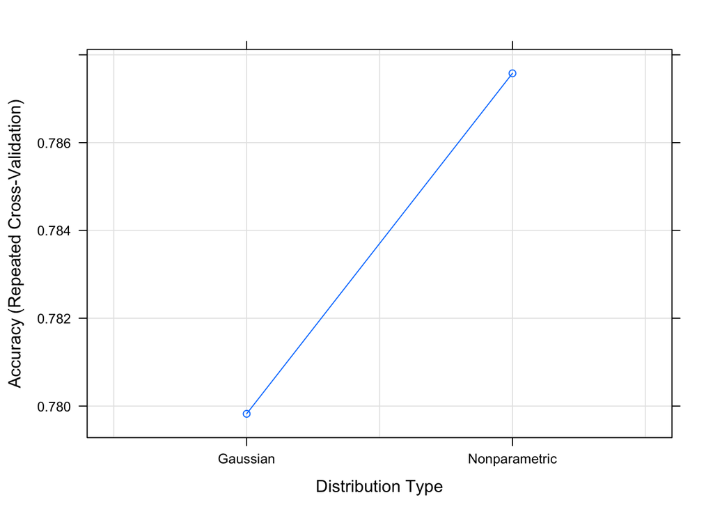

```r
plot(nb_model)
```

Use the trained `NB` model to predict labels:

```r
nb_predict <- suppressWarnings(predict(nb_model,newdata = testing ))
```

Again, the `predict` function prints out some debugging information that you can ignore.

```r
#Get the confusion matrix to see accuracy value and other parameter values
confusionMatrix(nb_predict, testing$SkillLevel )
```

```
## Confusion Matrix and Statistics
##
##           Reference
## Prediction   0   1   2   3
##          0 106  17   0   1
##          1   5  55   1   0
##          2   0  19   3   2
##          3   0   6   0   0
##
## Overall Statistics
##
##                Accuracy : 0.7628
##                  95% CI : (0.7002, 0.818)
##     No Information Rate : 0.5163
##     P-Value [Acc > NIR] : 9.071e-14
##
##                   Kappa : 0.5851
##
##  Mcnemar's Test P-Value : NA
##
## Statistics by Class:
##
##                      Class: 0 Class: 1 Class: 2 Class: 3
## Sensitivity            0.9550   0.5670  0.75000  0.00000
## Specificity            0.8269   0.9492  0.90047  0.97170
## Pos Pred Value         0.8548   0.9016  0.12500  0.00000
## Neg Pred Value         0.9451   0.7273  0.99476  0.98565
## Prevalence             0.5163   0.4512  0.01860  0.01395
## Detection Rate         0.4930   0.2558  0.01395  0.00000
## Detection Prevalence   0.5767   0.2837  0.11163  0.02791
## Balanced Accuracy      0.8909   0.7581  0.82524  0.48585
```

Note that there is another implementation of `Naive Bayes` in `caret` from the library `naivebayes`, with method name “naive_bayes” instead of “nb”. Check it out [here](https://cran.r-project.org/web/packages/naivebayes/naivebayes.pdf).

# Conclusion

In this lab, we showed how to train `Naive Bayes` models for classification tasks, using the *caret* package’s wrapper of the Naive Bayes implementation from the *klaR* package.